# RNA-seq in Bioconductor exercises

Tom Carroll

In todays session we will work with some of the RNA-seq data of T-regulatory cells from Christina Leslie’s lab.

Sequencing data as a FastQ file [can be found here.](https://www.encodeproject.org/files/ENCFF070QMF/@@download/ENCFF070QMF.fastq.gz)

Aligned data as a BAM file [can be found here.](https://www.encodeproject.org/files/ENCFF906UTB/@@download/ENCFF906UTB.bam)

## RNA-seq analysis.

1. Download the above FastQ file for T-regulatory cells (replicate 2) - **ENCFF070QMF.fastq.gz**. Sample 100000 reads from file and produce our 3 standard plots - the DNA base occurence over cycles, histogram of quality scores and a boxplot of quality scores (for first 10000 reads sampled to save memory).

```r
library(ShortRead)
library(ggplot2)

fqSample <- FastqSampler("~/Downloads/ENCFF070QMF.fastq.gz",n=10^5)
fastq <- yield(fqSample)
fastq
```

```
## class: ShortReadQ
## length: 100000 reads; width: 50 cycles
```

```r
readSequences <- sread(fastq)
readSequences_AlpbyCycle <- alphabetByCycle(readSequences)
readSequences_AlpbyCycle[1:4,1:4]
```

```
##         cycle
## alphabet  [,1]  [,2]  [,3]  [,4]
##        A 29205 27797 26142 26456
##        C 25632 21278 24173 24295
##        G 20854 25459 23578 23440
##        T 24264 25464 26107 25809
```

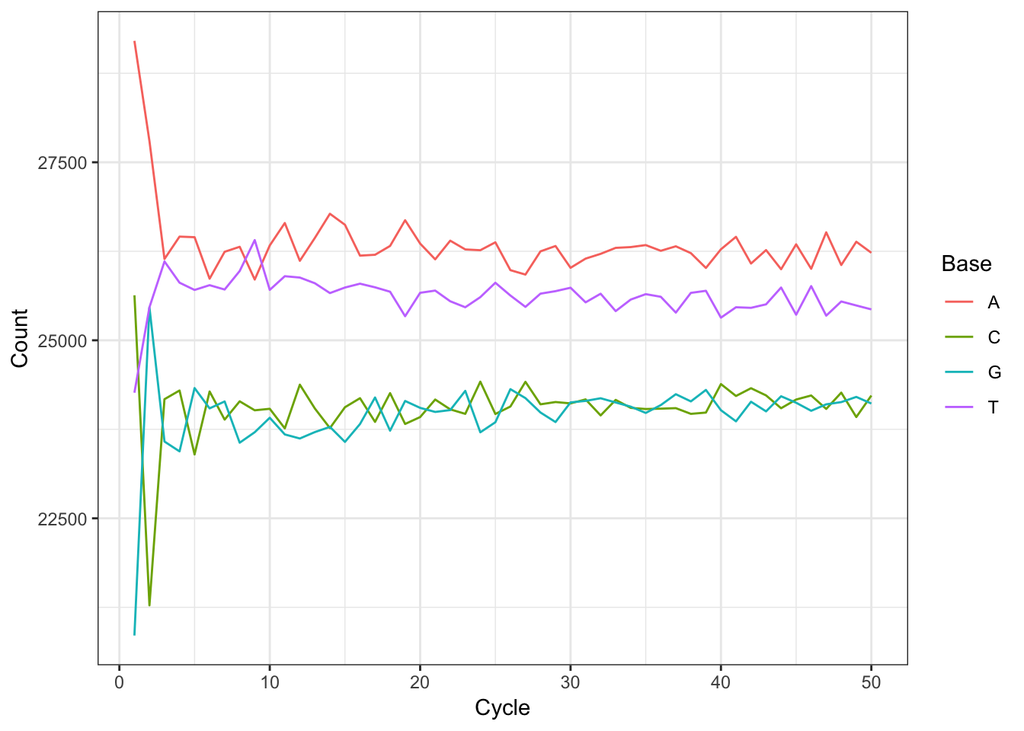

```r
AFreq <- readSequences_AlpbyCycle["A",]
CFreq <- readSequences_AlpbyCycle["C",]
GFreq <- readSequences_AlpbyCycle["G",]
TFreq <- readSequences_AlpbyCycle["T",]
toPlot <- data.frame(Count=c(AFreq,CFreq,GFreq,TFreq),
                     Cycle=rep(1:50,4),
                     Base=rep(c("A","C","G","T"),each=50))
ggplot(toPlot,aes(y=Count,x=Cycle,colour=Base))+geom_line()+theme_bw()
```

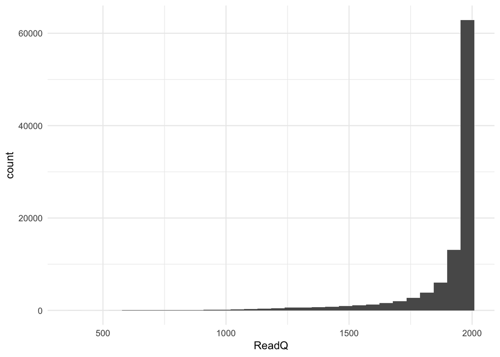

```r
readQuality <- quality(fastq)
readQualityScores <- alphabetScore(readQuality)

toPlot <- data.frame(ReadQ=readQualityScores)
ggplot(toPlot,aes(x=ReadQ))+geom_histogram()+theme_minimal()
```

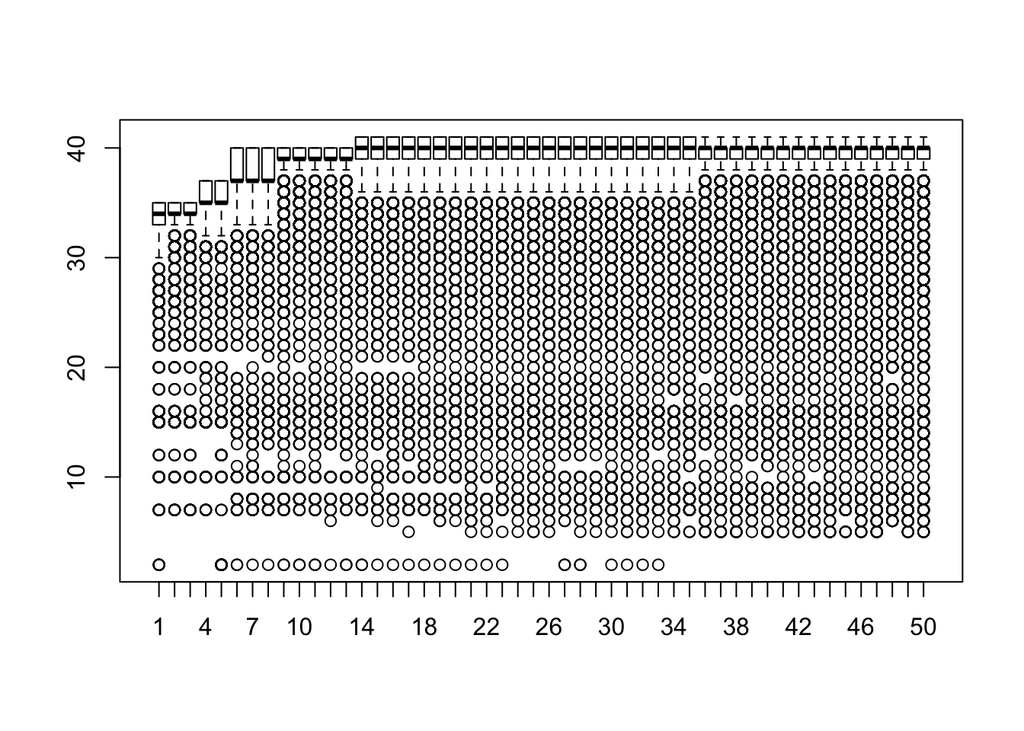

```r
qualAsMatrix <- as(readQuality,"matrix")
boxplot(qualAsMatrix[1:10000,])
```

2. Remove reads with summed qualities less than 1000 and write to a new fastQ file.

```r
fastqFilt <- fastq[readQualityScores >= 1000]
writeFastq(fastqFilt,"filtered_ENCFF070QMF.fastq.gz")
```

```r
library(BSgenome.Mmusculus.UCSC.mm10)

mainChromosomes <- paste0("chr10")
mainChrSeq <- lapply(mainChromosomes,
                     function(x)BSgenome.Mmusculus.UCSC.mm10[[x]])
names(mainChrSeq) <- mainChromosomes
mainChrSeqSet <- DNAStringSet(mainChrSeq)
writeXStringSet(mainChrSeqSet,
                "mm10Chr10.fa")


## QuasR
FileName <- "filtered_ENCFF070QMF.fastq.gz"
SampleName <- "Treg_2"
sampleTable <- data.frame(FileName,SampleName)
write.table(sampleTable,file="sampleTable.txt",sep="\t",
            quote=FALSE,row.names = FALSE)
library(QuasR)
qAlign("sampleTable.txt","mm10Chr10.fa",
       splicedAlignment=TRUE)



## Rsubread
library(Rsubread)
buildindex("mm10Chr10",
           "mm10Chr10.fa")
subjunc("mm10Chr10",
      "filtered_ENCFF070QMF.fastq.gz",
      output_file="Treg_2.bam")


sortBam("Treg_2.bam","Sorted_Treg_2")
indexBam("Sorted_Treg_2.bam")
```

4. Count the reads in our newly aligned and indexed BAM file mapping within genes. Plot a density plot of log 10 of reads counts across genes on chromosome 10. (Add 1 read to all counts to avoid log2 of zero)

```r
library(TxDb.Mmusculus.UCSC.mm10.knownGene)
```

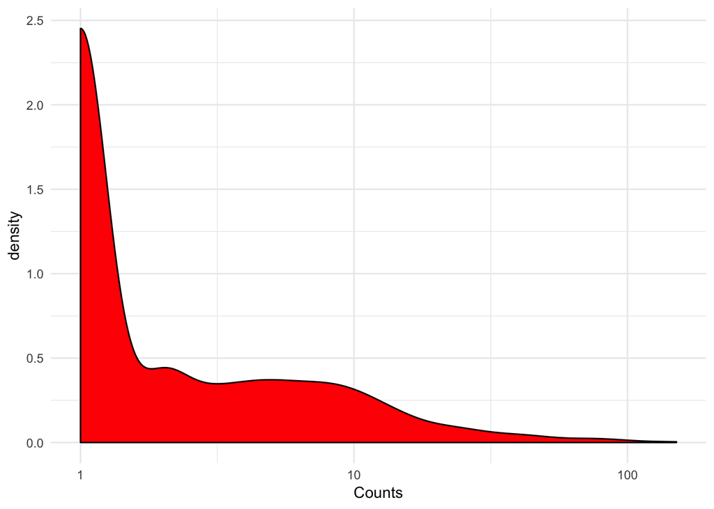

```r
geneExons <- exonsBy(TxDb.Mmusculus.UCSC.mm10.knownGene,by="gene")
library(GenomicAlignments)
myBam <- BamFile("Sorted_Treg_2.bam",yieldSize = 10000)
treg2GeneCounts <- summarizeOverlaps(geneExons,myBam,
                                    ignore.strand = TRUE)

myGeneGR <- rowRanges(treg2GeneCounts)
treg2GeneCountsChr10 <- treg2GeneCounts[all(seqnames(myGeneGR) ==
    "chr10"),]
treg2GeneCountsChr10Matrix <- assay(treg2GeneCountsChr10)+1
myCounts <- data.frame(Counts =treg2GeneCountsChr10Matrix[,1])
ggplot(myCounts,aes(x=Counts))+geom_density(fill="Red")+scale_x_log10()+theme_minimal()
```

5. (Optional) Download and install Salmon.

Using Salmon, quantify transcript levels using reads from our filtered fastq.

```r
allTxSeq <- extractTranscriptSeqs(BSgenome.Mmusculus.UCSC.mm10,
                      TxDb.Mmusculus.UCSC.mm10.knownGene,
                      use.names=TRUE)
allTxSeq
writeXStringSet(allTxSeq,
                "mm10Trans.fa")


salmonExec <- "~/bin/salmon index"
fastaTx <- "mm10Trans.fa"
indexName <- "mm10Trans"
salmonIndexCmd <- paste(salmonExec,
                        "-i",indexName,
                        "-t",fastaTx)
salmonIndexCmd
system(salmonIndexCmd,wait = TRUE)

salmonExec <- "~/bin/salmon quant"
fq <- "~/Downloads/filtered_ENCFF070QMF.fastq.gz"
outDir <- "TReg_2_Quant"
salmonQuantCmd <- paste(salmonExec,
                        "-i",indexName,
                        "-r",fq,
                        "-o",outDir,
                        "-l A")
salmonQuantCmd
system(salmonIndexCmd,wait = TRUE)
```

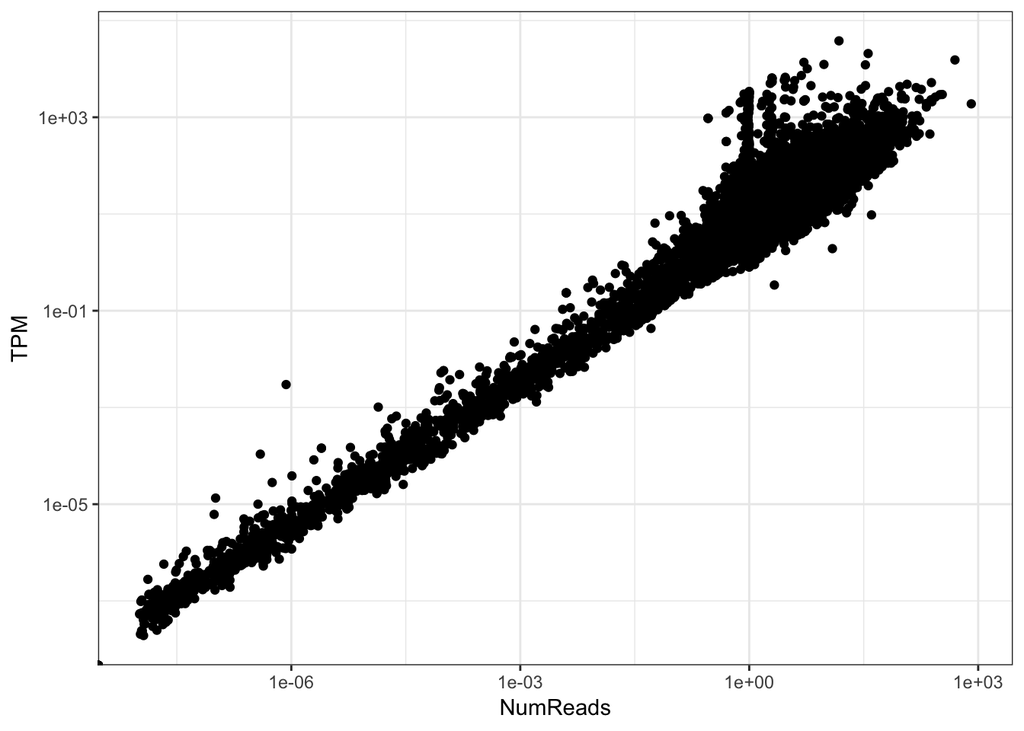

```r
myQuant <- read.delim("TReg_2_Quant/quant.sf")
ggplot(myQuant,aes(x=NumReads,y=TPM))+geom_point()+scale_x_log10()+scale_y_log10()+theme_bw()
```